# Optimal Systolic Blood Pressure Target in Resistant and Non-Resistant Hypertension: A Pooled Analysis of Patient-Level Data from SPRINT and ACCORD - ScienceDirect

### Cardiovascular Outcomes and Death

Tests for heterogeneity of outcomes by treatment assignment and original study are summarized in Supplemental Figure S5 (available online). Outcome-specific numbers of events and crude incidence rates are summarized inTable 2. Major adverse events occurred at a consistently higher rate in those with apparent resistant versus non-resistant hypertension for all outcomes (*P* < .05 for myocardial infarction, all-cause death; p < 0.005 for all others). Among those with apparent resistant hypertension, crude incidence rates for all outcomes except myocardial infarction and stroke were significantly lower in the intensive vs standard arm. Among the non-resistant hypertension cohort, crude incidence rates of the hybrid primary outcome and stroke were significantly lower for patients in the intensive vs standard arm. Cumulative incidence curves for each outcome are displayed in Figures 2 and 3. No significant interactions were observed between resistant hypertension status and treatment assignment for any outcome, suggesting that hypertension status did not influence the relative benefit (or lack thereof) of an intensive blood pressure target (Figure 4).

Table 2. Number of Events and Crude Incidence Rates (95% CIs) of Outcomes, by Resistant Hypertension Status Overall and by Treatment Assignment*

| Empty Cell Outcome | Apparent Resistant Hypertension Overall (n = 2710) | Apparent Resistant Hypertension Intensive (n = 1337) | Apparent Resistant Hypertension Standard (n = 1373) | Non-Resistant Hypertension Overall (n = 11,383) | Non-Resistant Hypertension Intensive (n = 5702) | Non-Resistant Hypertension Standard (n = 5681) |
| --- | --- | --- | --- | --- | --- | --- |
| **PO<sub>ACCORD</sub>** |  |  |  |  |  |  |
| No. events | 195 | 76 | 119 | 644 | 302 | 342 |
| Follow-up, y | 9483 | 4674 | 4809 | 42,162 | 21,113 | 21,048 |
| IR (95% CI) | 20.6 (17.9-23.7) | 16.3 (13.0-20.4) | 24.7 (20.7-29.6) | 15.3 (14.1-16.5) | 14.3 (12.8-16.0) | 16.2 (14.6-18.1) |
| **PO<sub>HYBRID</sub>** |  |  |  |  |  |  |
| No. events | 269 | 108 | 161 | 782 | 357 | 425 |
| Follow-up, y | 9338 | 4611 | 4727 | 41,913 | 21,004 | 20,909 |
| IR (95% CI) | 28.8 (25.6-32.5) | 23.4 (19.4-28.3) | 34.1 (29.2-39.8) | 18.7 (17.4-20.0) | 16.9 (15.3-18.9) | 20.3 (18.5-22.4) |
| **MI** |  |  |  |  |  |  |
| No. events | 107 | 43 | 64 | 378 | 180 | 198 |
| Follow-up, y | 9566 | 4717 | 4849 | 42,378 | 21,187 | 21,190 |
| IR (95% CI) | 11.2 (9.3-13.5) | 9.1 (6.8-12.3) | 13.2 (10.3-16.9) | 8.9 (8.1-9.9) | 8.5 (7.3-9.8) | 9.3 (8.1-10.7) |
| **Stroke** |  |  |  |  |  |  |
| No. events | 59 | 30 | 29 | 171 | 68 | 103 |
| Follow-up, y | 9651 | 4741 | 4911 | 42,878 | 21,440 | 21,438 |
| IR (95% CI) | 6.1 (4.7-7.9) | 6.3 (4.4-9.1) | 5.9 (4.1-8.5) | 4.0 (3.4-4.6) | 3.2 (2.5-4.0) | 4.8 (4.0-5.8) |
| **Heart failure** |  |  |  |  |  |  |
| No. events | 113 | 45 | 68 | 223 | 100 | 123 |
| Follow-up, y | 9568 | 4718 | 4850 | 42,773 | 21,376 | 21,397 |
| IR (95% CI) | 11.8 (9.8-14.2) | 9.5 (7.1-12.8) | 14.0 (11.1-17.8) | 5.2 (4.6-5.9) | 4.7 (3.8-5.7) | 5.7 (4.8-6.9) |
| **CV death** |  |  |  |  |  |  |
| No. events | 58 | 19 | 39 | 162 | 78 | 84 |
| Follow-up, y | 9780 | 4806 | 4974 | 43,255 | 21,590 | 21,666 |
| IR (95% CI) | 5.9 (4.6-7.7) | 4.0 (2.5-6.2) | 7.8 (5.7-10.7) | 3.7 (3.2-4.4) | 3.6 (2.9-4.5) | 3.9 (3.1-4.8) |
| **All-cause death** |  |  |  |  |  |  |
| No. events | 142 | 58 | 84 | 517 | 247 | 270 |
| Follow-up, y | 9855 | 4849 | 5006 | 43,676 | 21,784 | 21,892 |
| IR (95% CI) | 14.4 (12.2-17.0) | 12.0 (9.2-15.5) | 16.8 (13.5-20.8) | 11.8 (10.9-12.9) | 11.3 (10.0-12.8) | 12.3 (10.9-13.9) |

CI = confidence interval; CV = cardiovascular; IR = incidence rate; MI = myocardial infarction.

**⁎**

Incidence rates are per 1000 patient-years. PO<sub>ACCORD</sub> is first occurrence of myocardial infarction, stroke, or cardiovascular death. PO<sub>HYBRID</sub> is first occurrence of myocardial infarction, stroke, heart failure, or cardiovascular death.

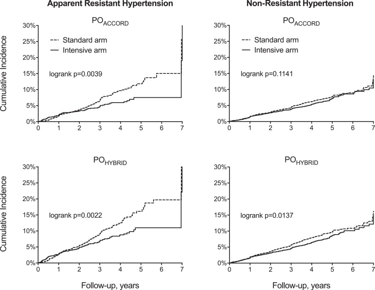

Figure 2. Cumulative incidence for each composite outcome, comparing treatment assignments. Data are stratified by baseline apparent resistant hypertension (left column) and non-resistant hypertension (right column).

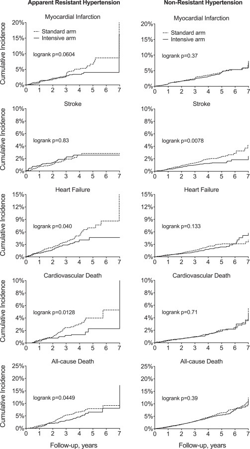

Figure 3. Cumulative incidence for each individual outcome, comparing treatment assignments. Data are stratified by baseline apparent resistant hypertension (left column) and non-resistant hypertension (right column).

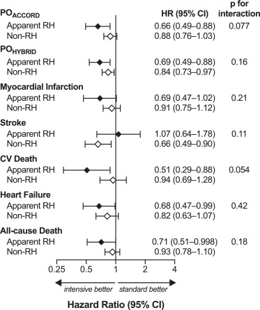

Figure 4. Tests for interactions between treatment assignment and baseline resistant hypertension status. PO<sub>ACCORD</sub> is first occurrence of myocardial infarction, stroke, or cardiovascular death. PO<sub>HYBRID</sub> is first occurrence of myocardial infarction, stroke, heart failure, or cardiovascular death. CV = cardiovascular; RH = resistant hypertension.

In full models adjusting for baseline hypertension status and other covariates, intensive treatment significantly reduced the risk of the ACCORD-BP primary outcome (hazard ratio [HR] 0.81; 95% confidence interval [CI], 0.71-0.93), hybrid primary outcome (HR, 0.78; 95% CI, 0.69-0.88), stroke (HR 0.72; 95% CI, 0.55-0.94), and heart failure (HR 0.73; 95% CI, 0.59-0.91). The intensive systolic target also appeared to reduce risk of myocardial infarction (HR 0.85; 95% CI, 0.71-1.02), cardiovascular death (HR 0.79; 95% CI, 0.60-1.03), and all-cause death (HR 0.87; 95% CI, 0.74-1.01), though in each case the confidence interval bounded 1. Apparent resistant hypertension also independently predicted increased risk of the hybrid primary outcome (HR 1.30; 95% CI 1.12-1.50) and heart failure (HR 1.89; 95% CI, 1.50-2.37), but not the ACCORD primary outcome, myocardial infarction, stroke, cardiovascular death, or all-cause death. Full model results for the composite and individual outcomes are displayed in Supplemental Figures S6 and S7 (available online), respectively. Similar results were observed in sensitivity analyses defining resistant hypertension status at 6 months (data not shown).

## Discussion

While we understand the importance of controlling blood pressure among patients with resistant hypertension, concrete information on blood pressure targets in this high-risk population remains sparse. To a large degree, our insight is hindered by hurdles related to extrapolation of data from studies of the general hypertensive population.13, 20<sup>,</sup><sup>21</sup> For the first time, we demonstrate that patients with apparent resistant hypertension benefit similarly from an intensive systolic blood pressure target, compared with those with non-resistant hypertension. Furthermore, we provide evidence to support that, regardless of the presence or absence of resistant hypertension, an intensive systolic target is beneficial for most major cardiovascular outcomes and death across a diverse population of hypertensive individuals, including those with [normoglycemia](https://www.sciencedirect.com/topics/nursing-and-health-professions/glucose-blood-level), pre-diabetes, and diabetes, and in those with and without a history of stroke. Finally, we demonstrate that the updated definition for resistant hypertension proposed in the 2017 hypertension guidelines<sup>13</sup> identifies a higher-risk hypertensive subpopulation. To our knowledge, this is the first study of major outcomes using this updated definition.

Prior studies have had mixed results with regard to the benefits of blood pressure-lowering or achieving control (to <140/90 mm Hg) in resistant hypertension. For example, among a hypertensive [coronary artery disease](https://www.sciencedirect.com/topics/nursing-and-health-professions/coronary-artery-disease) population, no difference in outcomes was observed comparing controlled and uncontrolled resistant hypertension, despite a substantial differential in [mean blood pressure](https://www.sciencedirect.com/topics/nursing-and-health-professions/mean-arterial-pressure) (28/10 mm Hg).<sup>5</sup> Similar findings were observed in hypertensive diabetics, where controlled (vs uncontrolled) resistant hypertension was not associated with improved renal outcomes.<sup>15</sup> Others have shown attenuated benefits in those with controlled versus uncontrolled resistant hypertension,<sup>14</sup> or benefits only on certain outcomes.<sup>8</sup> However, these prior findings were largely from observational [cohort studies](https://www.sciencedirect.com/topics/nursing-and-health-professions/cohort-analysis) testing associations between achieved blood pressure and outcomes, and such studies may suffer from issues of confounding or time-related biases inadvertently introduced by study design. The present analysis used prospective clinical trial data that tested random assignment to an intensive or standard systolic BP and therefore is less likely to suffer from some of the limitations inherent to observational research.

It is noteworthy that patients with apparent resistant hypertension, who by definition have more difficult-to-treat hypertension, achieved relatively rapid blood pressure lowering, resulting in a mean 1-year blood pressure of 124/68 mm Hg in the intensive arm with addition of approximately 1 antihypertensive drug. That blood pressure control improved from 6% at baseline to 64% at 12 months in this group, suggesting that significantly improved long-term blood pressure control, using updated blood pressure targets, is achievable in most patients with resistant hypertension. However, 2 important factors in these trials, which are not always present in real-world treatment settings, should be highlighted. First, both trials provided most antihypertensive drugs free of charge. Interestingly, data from SPRINT suggest only a minority of patients with resistant hypertension in the intensive arm (<20% during any year-1 visit) required addition of new drugs to achieve target blood pressure. Secondly, protocols for both studies included frequent early follow-up (5-6 visits at which medications could be adjusted), and guidance on antihypertensive regimen [titration](https://www.sciencedirect.com/topics/nursing-and-health-professions/titrimetry).16, 17 Prior work suggests frequent follow-up and appropriate antihypertensive [medication titration](https://www.sciencedirect.com/topics/nursing-and-health-professions/drug-dose-titration) are effective in achieving rapid blood pressure control in this population.22, 23 Thus, there are at least 3 plausible explanations for our findings of rapid blood pressure target attainment. First, treatment adherence was suboptimal at enrollment and provision of free therapies improved adherence. Second, dose titrations contributed to rapid attainment of blood pressure control, in which case patients may have had suboptimal dosing at baseline. Third, semi-protocolized treatment approaches and frequent follow-up visits, per se, were associated with substantial [blood pressure reductions](https://www.sciencedirect.com/topics/medicine-and-dentistry/blood-pressure-reduction). Unfortunately, available SPRINT data did not allow for assessment of medication doses, titrations, or adherence.

Our study has notable strengths, including pooling of patient-level data from 2 large randomized trials encompassing a diverse high-risk hypertensive population. Both trials had remarkably similar protocols and pre-specified outcomes, resulting in a large cohort of patients with apparent resistant hypertension with up to 7 years follow-up, and adjudicated outcomes relevant to the hypertensive population and cardiovascular disease generally. Nevertheless, some limitations are worthy of comment. First, although benefits of randomization appear to have been conserved, strengthening the case for causal inference, we cannot be sure that unmeasured factors were equally distributed between treatment arms within the resistant hypertension group. Second, our definition for resistant hypertension was not inclusive of a [thiazide](https://www.sciencedirect.com/topics/nursing-and-health-professions/thiazide-diuretic-agent) because patient-level drug data were unavailable for SPRINT. However, prior studies have shown no difference in outcome risk comparing resistant hypertension definitions inclusive vs exclusive of thiazides.5, 24 Third, we were unable to exclude pseudoresistance: out-of-office blood pressure was not measured in most patients; adherence data were unavailable in SPRINT, although ACCORD-BP data suggest relatively few (<15%) with apparent resistant hypertension report nonadherence; and, secondary hypertension was not collected systematically, although SPRINT did exclude some patients with secondary hypertension. Thus, we cannot exclude the possibility that misclassifying pseudoresistant hypertension as resistant hypertension biased our results. However, any such bias would be expected to conservatively estimate intensive treatment benefits in resistant hypertension. And, our sensitivity analyses suggest that pseudoresistance did not substantially influence our results. Finally, both trials excluded refractory hypertension. Thus, we cannot say whether lower blood pressure benefits this group.

In conclusion, we provide evidence that an intensive systolic target reduces risk of adverse cardiovascular events including death in apparent resistant hypertension. These findings provide confidence in recently revised guidance to target lower blood pressure (<130/80 mm Hg) in this population.<sup>13</sup> Additional studies are needed to better understand optimal treatments to maximally reduce risk, as well as medication-related adverse effects with more intensive treatment in this population, because most patients will require second-line antihypertensives associated with more adverse effects and lower quality of life.